# Capstone Project NLP Chatbot Interface

# DOMAIN

Industrial safety. NLP based Chatbot.

# CONTEXT:

The database comes from one of the biggest industry in Brazil and in the world. It is an urgent need for industries/companies around the globe to understand why employees still suffer some injuries/accidents in plants. Sometimes they also die in such environment.

# DATA DESCRIPTION:

This The database is basically records of accidents from 12 different plants in 03 different countries which every line in the data is an occurrence of an accident.

# Columns description:

1. Data: timestamp or time/date information
2. Countries: which country the accident occurred (anonymised)
3. Local: the city where the manufacturing plant is located (anonymised)
4. Industry sector: which sector the plant belongs to
5. Accident level: from I to VI, it registers how severe was the accident (I means not severe but VI means very severe)
6. Potential Accident Level: Depending on the Accident Level, the database also registers how severe the accident could have been (due to other factors involved in the accident)
7. Genre: if the person is male of female
8. Employee or Third Party: if the injured person is an employee or a third party
9. Critical Risk: some description of the risk involved in the accident
10. Description: Detailed description of how the accident happened. Link to download the dataset: https://www.kaggle.com/ihmstefanini/industrial-safety-and-health-analytics-database [ for your reference only ] #PROJECT OBJECTIVE: Design a ML/DL based chatbot utility which can help the professionals to highlight the safety risk as per the incident description.

# Target:

Dataset Consisting of many columns, important column is description column which gives information on detailed description of an accident. Our target column is to predict the accident level. using chatbot interface.

In target column I means not severe and V means very severe

```python
import numpy as np
import pandas as pd
import matplotlib.pyplot as plt
%matplotlib inline

import seaborn as sns

import tensorflow as tf
tf.__version__
```

```
'2.8.2'
```

```python
from google.colab import drive
drive.mount('/content/gdrive')
```

```python
df=pd.read_csv('gdrive/My Drive/Colab Notebooks/IHMStefanini_industrial_safety_and_health_database_with_accidents_description.csv')
```

```python
df.head(10)
```

|  | Unnamed: 0 | Data | Countries | Local | Industry Sector | Accident Level | Potential Accident Level | Genre | Employee or Third Party | Critical Risk | Description |
| --- | --- | --- | --- | --- | --- | --- | --- | --- | --- | --- | --- |
| 0 | 0 | 2016-01-01 00:00:00 | Country_01 | Local_01 | Mining | I | IV | Male | Third Party | Pressed | While removing the drill rod of the Jumbo 08 f... |
| 1 | 1 | 2016-01-02 00:00:00 | Country_02 | Local_02 | Mining | I | IV | Male | Employee | Pressurized Systems | During the activation of a sodium sulphide pum... |
| 2 | 2 | 2016-01-06 00:00:00 | Country_01 | Local_03 | Mining | I | III | Male | Third Party (Remote) | Manual Tools | In the sub-station MILPO located at level +170... |
| 3 | 3 | 2016-01-08 00:00:00 | Country_01 | Local_04 | Mining | I | I | Male | Third Party | Others | Being 9:45 am. approximately in the Nv. 1880 C... |
| 4 | 4 | 2016-01-10 00:00:00 | Country_01 | Local_04 | Mining | IV | IV | Male | Third Party | Others | Approximately at 11:45 a.m. in circumstances t... |
| 5 | 5 | 2016-01-12 00:00:00 | Country_02 | Local_05 | Metals | I | III | Male | Third Party (Remote) | Pressurized Systems | During the unloading operation of the ustulado... |
| 6 | 6 | 2016-01-16 00:00:00 | Country_02 | Local_05 | Metals | I | III | Male | Employee | Fall prevention (same level) | The collaborator reports that he was on street... |
| 7 | 7 | 2016-01-17 00:00:00 | Country_01 | Local_04 | Mining | I | III | Male | Third Party | Pressed | At approximately 04:50 p.m., when the mechanic... |
| 8 | 8 | 2016-01-19 00:00:00 | Country_02 | Local_02 | Mining | I | IV | Male | Third Party (Remote) | Others | Employee was sitting in the resting area at le... |
| 9 | 9 | 2016-01-26 00:00:00 | Country_01 | Local_06 | Metals | I | II | Male | Third Party | Chemical substances | At the moment the forklift operator went to ma... |

```python
df.shape
```

```
(425, 11)
```

Dataset has 425 rows and 11 columns

```python
df.isnull().sum()
```

```
Unnamed: 0                  0
Data                        0
Countries                   0
Local                       0
Industry Sector             0
Accident Level              0
Potential Accident Level    0
Genre                       0
Employee or Third Party     0
Critical Risk               0
Description                 0
dtype: int64
```

No Null Values found

```python
df.info()
```

```
<class 'pandas.core.frame.DataFrame'>
RangeIndex: 425 entries, 0 to 424
Data columns (total 11 columns):
 #   Column                    Non-Null Count  Dtype
---  ------                    --------------  -----
 0   Unnamed: 0                425 non-null    int64
 1   Data                      425 non-null    object
 2   Countries                 425 non-null    object
 3   Local                     425 non-null    object
 4   Industry Sector           425 non-null    object
 5   Accident Level            425 non-null    object
 6   Potential Accident Level  425 non-null    object
 7   Genre                     425 non-null    object
 8   Employee or Third Party   425 non-null    object
 9   Critical Risk             425 non-null    object
 10  Description               425 non-null    object
dtypes: int64(1), object(10)
memory usage: 36.6+ KB
```

All columns are Categorical except first column and data column is actually date and timestamp

We can remove first column and modify the names of columns

```python
df.drop("Unnamed: 0", axis=1, inplace=True)
df.rename(columns={'Data':'Date', 'Countries':'Country', 'Genre':'Gender', 'Employee or Third Party':'Employee type'}, inplace=True)
df.head(5)
```

|  | Date | Country | Local | Industry Sector | Accident Level | Potential Accident Level | Gender | Employee type | Critical Risk | Description |
| --- | --- | --- | --- | --- | --- | --- | --- | --- | --- | --- |
| 0 | 2016-01-01 00:00:00 | Country_01 | Local_01 | Mining | I | IV | Male | Third Party | Pressed | While removing the drill rod of the Jumbo 08 f... |
| 1 | 2016-01-02 00:00:00 | Country_02 | Local_02 | Mining | I | IV | Male | Employee | Pressurized Systems | During the activation of a sodium sulphide pum... |
| 2 | 2016-01-06 00:00:00 | Country_01 | Local_03 | Mining | I | III | Male | Third Party (Remote) | Manual Tools | In the sub-station MILPO located at level +170... |
| 3 | 2016-01-08 00:00:00 | Country_01 | Local_04 | Mining | I | I | Male | Third Party | Others | Being 9:45 am. approximately in the Nv. 1880 C... |
| 4 | 2016-01-10 00:00:00 | Country_01 | Local_04 | Mining | IV | IV | Male | Third Party | Others | Approximately at 11:45 a.m. in circumstances t... |

```python
df.duplicated().sum()
```

```
7
```

There were 7 duplicate values found and we can drop the duplicate values as there were very few values which will not affect the dataset

```python
duplicates = df.duplicated()
df[duplicates]
```

|  | Date | Country | Local | Industry Sector | Accident Level | Potential Accident Level | Gender | Employee type | Critical Risk | Description |
| --- | --- | --- | --- | --- | --- | --- | --- | --- | --- | --- |
| 77 | 2016-04-01 00:00:00 | Country_01 | Local_01 | Mining | I | V | Male | Third Party (Remote) | Others | In circumstances that two workers of the Abrat... |
| 262 | 2016-12-01 00:00:00 | Country_01 | Local_03 | Mining | I | IV | Male | Employee | Others | During the activity of chuteo of ore in hopper... |
| 303 | 2017-01-21 00:00:00 | Country_02 | Local_02 | Mining | I | I | Male | Third Party (Remote) | Others | Employees engaged in the removal of material f... |
| 345 | 2017-03-02 00:00:00 | Country_03 | Local_10 | Others | I | I | Male | Third Party | Venomous Animals | On 02/03/17 during the soil sampling in the re... |
| 346 | 2017-03-02 00:00:00 | Country_03 | Local_10 | Others | I | I | Male | Third Party | Venomous Animals | On 02/03/17 during the soil sampling in the re... |
| 355 | 2017-03-15 00:00:00 | Country_03 | Local_10 | Others | I | I | Male | Third Party | Venomous Animals | Team of the VMS Project performed soil collect... |
| 397 | 2017-05-23 00:00:00 | Country_01 | Local_04 | Mining | I | IV | Male | Third Party | Projection of fragments | In moments when the 02 collaborators carried o... |

```python
df.drop_duplicates(inplace=True)
```

```python
df.shape
```

```
(418, 10)
```

```python
print('********** Date ***********')
print(df['Date'].unique())
print('********* Country ***********')
print(df['Country'].unique())
print('********* Local ***********')
print(df['Local'].unique())
print('****** Industry Sector *********')
print(df['Industry Sector'].unique())
print('******** Accident Level ********')
print(df['Accident Level'].unique())
print('****Potential Accident Level******')
print(df['Potential Accident Level'].unique())
print('********Gender************')
print(df['Gender'].unique())
print('*******Employee type*********')
print(df['Employee type'].unique())
print('******Critical Risk********')
print(df['Critical Risk'].unique())
```

```
********** Date ***********
['2016-01-01 00:00:00' '2016-01-02 00:00:00' '2016-01-06 00:00:00'
 '2016-01-08 00:00:00' '2016-01-10 00:00:00' '2016-01-12 00:00:00'
 '2016-01-16 00:00:00' '2016-01-17 00:00:00' '2016-01-19 00:00:00'
 '2016-01-26 00:00:00' '2016-01-28 00:00:00' '2016-01-30 00:00:00'
 '2016-02-01 00:00:00' '2016-02-02 00:00:00' '2016-02-04 00:00:00'
 '2016-02-06 00:00:00' '2016-02-07 00:00:00' '2016-02-08 00:00:00'
 '2016-02-21 00:00:00' '2016-02-25 00:00:00' '2016-02-09 00:00:00'
 '2016-02-10 00:00:00' '2016-02-15 00:00:00' '2016-02-14 00:00:00'
 '2016-02-13 00:00:00' '2016-02-16 00:00:00' '2016-02-17 00:00:00'
 '2016-02-19 00:00:00' '2016-02-20 00:00:00' '2016-02-18 00:00:00'
 '2016-02-22 00:00:00' '2016-02-24 00:00:00' '2016-02-29 00:00:00'
 '2016-02-26 00:00:00' '2016-02-27 00:00:00' '2016-03-02 00:00:00'
 '2016-03-03 00:00:00' '2016-03-04 00:00:00' '2016-03-05 00:00:00'
 '2016-03-06 00:00:00' '2016-03-09 00:00:00' '2016-03-11 00:00:00'
 '2016-03-13 00:00:00' '2016-03-12 00:00:00' '2016-03-14 00:00:00'
 '2016-03-16 00:00:00' '2016-03-10 00:00:00' '2016-03-17 00:00:00'
 '2016-03-18 00:00:00' '2016-03-19 00:00:00' '2016-03-22 00:00:00'
 '2016-03-25 00:00:00' '2016-03-30 00:00:00' '2016-03-31 00:00:00'
 '2016-04-01 00:00:00' '2016-04-03 00:00:00' '2016-04-02 00:00:00'
 '2016-03-24 00:00:00' '2016-04-04 00:00:00' '2016-04-05 00:00:00'
 '2016-04-07 00:00:00' '2016-04-08 00:00:00' '2016-04-11 00:00:00'
 '2016-04-14 00:00:00' '2016-04-16 00:00:00' '2016-04-15 00:00:00'
 '2016-04-17 00:00:00' '2016-04-18 00:00:00' '2016-04-21 00:00:00'
 '2016-04-22 00:00:00' '2016-04-23 00:00:00' '2016-04-26 00:00:00'
 '2016-04-28 00:00:00' '2016-04-29 00:00:00' '2016-04-30 00:00:00'
 '2016-05-01 00:00:00' '2016-05-02 00:00:00' '2016-05-04 00:00:00'
 '2016-05-03 00:00:00' '2016-05-05 00:00:00' '2016-05-11 00:00:00'
 '2016-05-12 00:00:00' '2016-05-14 00:00:00' '2016-05-17 00:00:00'
 '2016-05-19 00:00:00' '2016-05-18 00:00:00' '2016-05-22 00:00:00'
 '2016-05-20 00:00:00' '2016-05-24 00:00:00' '2016-05-25 00:00:00'
 '2016-05-27 00:00:00' '2016-05-26 00:00:00' '2016-06-01 00:00:00'
 '2016-06-02 00:00:00' '2016-06-03 00:00:00' '2016-06-04 00:00:00'
 '2016-06-05 00:00:00' '2016-06-08 00:00:00' '2016-06-07 00:00:00'
 '2016-06-10 00:00:00' '2016-06-13 00:00:00' '2016-06-16 00:00:00'
 '2016-06-18 00:00:00' '2016-06-17 00:00:00' '2016-06-19 00:00:00'
 '2016-06-21 00:00:00' '2016-06-22 00:00:00' '2016-06-23 00:00:00'
 '2016-06-24 00:00:00' '2016-06-29 00:00:00' '2016-07-02 00:00:00'
 '2016-07-04 00:00:00' '2016-07-08 00:00:00' '2016-07-07 00:00:00'
 '2016-07-09 00:00:00' '2016-07-10 00:00:00' '2016-07-11 00:00:00'
```

[output cut: 69 more lines]

```
['Male' 'Female']
*******Employee type*********
['Third Party' 'Employee' 'Third Party (Remote)']
******Critical Risk********
['Pressed' 'Pressurized Systems' 'Manual Tools' 'Others'
 'Fall prevention (same level)' 'Chemical substances' 'Liquid Metal'
 'Electrical installation' 'Confined space'
 'Pressurized Systems / Chemical Substances'
 'Blocking and isolation of energies' 'Suspended Loads' 'Poll' 'Cut'
 'Fall' 'Bees' 'Fall prevention' '\nNot applicable' 'Traffic' 'Projection'
 'Venomous Animals' 'Plates' 'Projection/Burning' 'remains of choco'
 'Vehicles and Mobile Equipment' 'Projection/Choco' 'Machine Protection'
 'Power lock' 'Burn' 'Projection/Manual Tools'
 'Individual protection equipment' 'Electrical Shock'
 'Projection of fragments']
```

1. Accidents are recorded from 2016.01.01 to 2017-07-09
2. Three countries are noted Country_01,Country_02 and Country_03. No specific name of country
3. 12 Local cities are mentioned
4. 3 industrial sectors are noted 'Mining' 'Metals' 'Others'
5. 5 accident levels are indicated 'I' 'II' 'III' 'IV' 'V'
6. 6 Potential Accident Levels are indicated I' 'II' 'III' 'IV' 'V' 'VI'
7. Genders are Male and Female
8. 3 Employee type 'Third Party' 'Employee' 'Third Party (Remote)'
9. lot of Critical risk descriptions

```python
df['Date'] = pd.to_datetime(df['Date'])

df['Year'] = df.Date.apply(lambda x : x.year)
df['Month'] = df.Date.apply(lambda x : x.month)
df['Day'] = df.Date.apply(lambda x : x.day)
df['Weekday'] = df.Date.apply(lambda x : x.day_name())
df['WeekofYear'] = df.Date.apply(lambda x : x.weekofyear)

df.head(5)
```

|  | Date | Country | Local | Industry Sector | Accident Level | Potential Accident Level | Gender | Employee type | Critical Risk | Description | Year | Month | Day | Weekday | WeekofYear |
| --- | --- | --- | --- | --- | --- | --- | --- | --- | --- | --- | --- | --- | --- | --- | --- |
| 0 | 2016-01-01 | Country_01 | Local_01 | Mining | I | IV | Male | Third Party | Pressed | While removing the drill rod of the Jumbo 08 f... | 2016 | 1 | 1 | Friday | 53 |
| 1 | 2016-01-02 | Country_02 | Local_02 | Mining | I | IV | Male | Employee | Pressurized Systems | During the activation of a sodium sulphide pum... | 2016 | 1 | 2 | Saturday | 53 |
| 2 | 2016-01-06 | Country_01 | Local_03 | Mining | I | III | Male | Third Party (Remote) | Manual Tools | In the sub-station MILPO located at level +170... | 2016 | 1 | 6 | Wednesday | 1 |
| 3 | 2016-01-08 | Country_01 | Local_04 | Mining | I | I | Male | Third Party | Others | Being 9:45 am. approximately in the Nv. 1880 C... | 2016 | 1 | 8 | Friday | 1 |
| 4 | 2016-01-10 | Country_01 | Local_04 | Mining | IV | IV | Male | Third Party | Others | Approximately at 11:45 a.m. in circumstances t... | 2016 | 1 | 10 | Sunday | 1 |

```python
'''
plt.figure(figsize=(15,10))
sns.countplot(x = 'Local',
              data = df,
              order = df['Local'].value_counts().index)
'''
```

```
"\nplt.figure(figsize=(15,10))\nsns.countplot(x = 'Local',\n              data = df,\n              order = df['Local'].value_counts().index)\n"
```

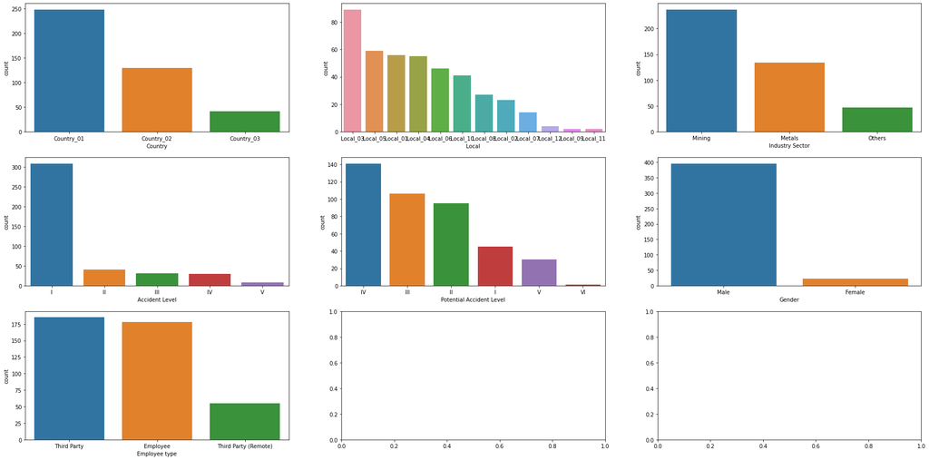

```python
count_plots=df.drop(['Date','Critical Risk','Description','Year','Month','Day','Weekday','WeekofYear']	, axis=1)

fig , ax = plt.subplots(3,3,figsize = (30,15))
for i , subplots in zip (count_plots , ax.flatten()):
  sns.countplot(count_plots[i],ax = subplots,order = count_plots[i].value_counts().index)
plt.show()
```

1. Country 1 has highest accidents. country 3 has lowest
2. Highest manufacturing plants are located in Local_03 city. Lowest manufacturing plants are located in Local_11 city
3. Highest Industry Sector are Mining
4. Accident Level I has more counts and V has less counts
5. Potential Accident level IV has more counts and VI has less
6. Male counts are more than Female counts
7. Employee type Third Party are more affected.

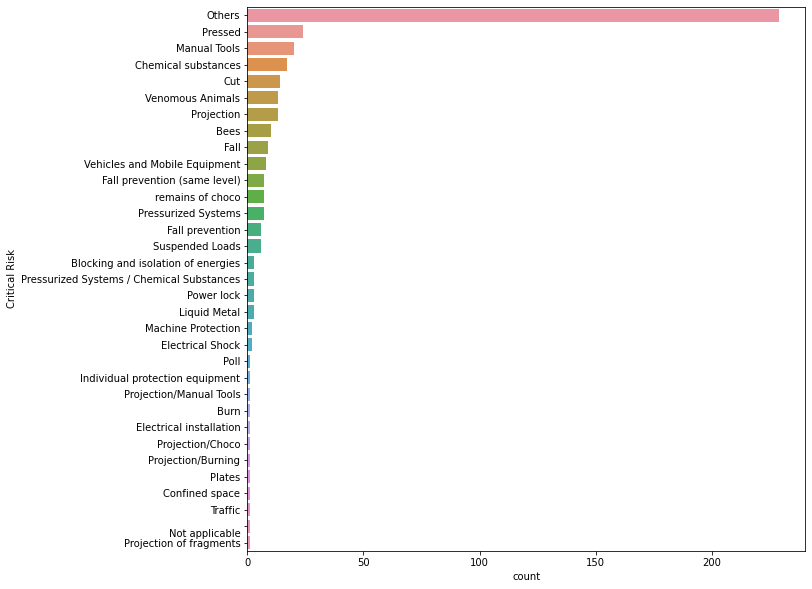

```python
plt.figure(figsize = (10,10))
sns.countplot(y =df['Critical Risk'],order = df['Critical Risk'].value_counts().index)
plt.show()
```

most part of the Critical Risks are classified as 'Others'

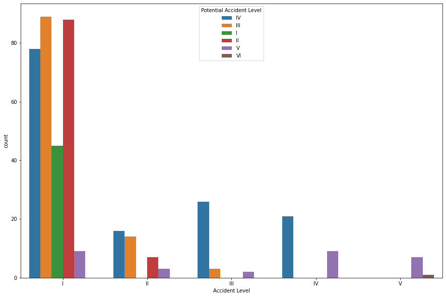

```python
plt.figure(figsize=(15,10))
sns.countplot(x = 'Accident Level',
              data = df,
              order = df['Accident Level'].value_counts().index, hue=df['Potential Accident Level'])
```

Potential of accidents level increases as the level of accident is I

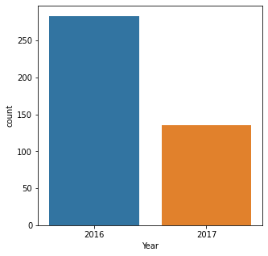

```python
plt.figure(figsize=(5,5))
sns.countplot(x = 'Year',
              data = df,
              order = df['Year'].value_counts().index)
```

Accidents in 2016 year are more than 2017

```python
print("Detail Summary")

df.drop(columns='Description').describe(exclude=[np.number]).T
```

```
Detail Summary
```

|  | count | unique | top | freq | first | last |
| --- | --- | --- | --- | --- | --- | --- |
| Date | 418 | 287 | 2017-02-08 00:00:00 | 6 | 2016-01-01 | 2017-07-09 |
| Country | 418 | 3 | Country_01 | 248 | NaT | NaT |
| Local | 418 | 12 | Local_03 | 89 | NaT | NaT |
| Industry Sector | 418 | 3 | Mining | 237 | NaT | NaT |
| Accident Level | 418 | 5 | I | 309 | NaT | NaT |
| Potential Accident Level | 418 | 6 | IV | 141 | NaT | NaT |
| Gender | 418 | 2 | Male | 396 | NaT | NaT |
| Employee type | 418 | 3 | Third Party | 185 | NaT | NaT |
| Critical Risk | 418 | 33 | Others | 229 | NaT | NaT |
| Weekday | 418 | 7 | Thursday | 76 | NaT | NaT |

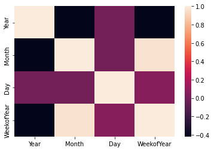

```python
sns.heatmap(df.corr())
```

Weekofyear has high correlation with Month

```python
import re
import numpy as np
import nltk
nltk.download('stopwords')
from nltk.corpus import stopwords
stopwords = set(stopwords.words('english'))

def preprocess_text(df, column_name=''):

  # Select only alphabets
  df[column_name] = df[column_name].apply(lambda x: re.sub('[^A-Za-z]+', ' ', x))

  # Convert text to lowercase
  df[column_name] = df[column_name].apply(lambda x: x.lower())

  # Strip unwanted spaces
  df[column_name] = df[column_name].apply(lambda x: x.strip())

  # Remove stopwords
  df[column_name] = df[column_name].apply(lambda x: ' '.join([word for word in x.split() if word not in stopwords]))

  # Replace empty strings with Null
  df[column_name].replace('', np.nan, inplace = True)

  # Drop Null values
  df = df.dropna()

  return df
```

```python
df = preprocess_text(df, column_name='Description')
df['Description'][0]
```

```
'removing drill rod jumbo maintenance supervisor proceeds loosen support intermediate centralizer facilitate removal seeing mechanic supports one end drill equipment pull hands bar accelerate removal moment bar slides point support tightens fingers mechanic drilling bar beam jumbo'
```

```python
df.head()
```

|  | Date | Country | Local | Industry Sector | Accident Level | Potential Accident Level | Gender | Employee type | Critical Risk | Description | Year | Month | Day | Weekday | WeekofYear |
| --- | --- | --- | --- | --- | --- | --- | --- | --- | --- | --- | --- | --- | --- | --- | --- |
| 0 | 2016-01-01 | Country_01 | Local_01 | Mining | I | IV | Male | Third Party | Pressed | removing drill rod jumbo maintenance superviso... | 2016 | 1 | 1 | Friday | 53 |
| 1 | 2016-01-02 | Country_02 | Local_02 | Mining | I | IV | Male | Employee | Pressurized Systems | activation sodium sulphide pump piping uncoupl... | 2016 | 1 | 2 | Saturday | 53 |
| 2 | 2016-01-06 | Country_01 | Local_03 | Mining | I | III | Male | Third Party (Remote) | Manual Tools | sub station milpo located level collaborator e... | 2016 | 1 | 6 | Wednesday | 1 |
| 3 | 2016-01-08 | Country_01 | Local_04 | Mining | I | I | Male | Third Party | Others | approximately nv cx ob personnel begins task u... | 2016 | 1 | 8 | Friday | 1 |
| 4 | 2016-01-10 | Country_01 | Local_04 | Mining | IV | IV | Male | Third Party | Others | approximately circumstances mechanics anthony ... | 2016 | 1 | 10 | Sunday | 1 |

```python
print('To Check length of each line');
df['line_length'] = df['Description'].str.len()
print('Minimum line length: {}'.format(df['line_length'].min()))
print('Maximum line length: {}'.format(df['line_length'].max()))
print('Line with maximum length: {}'.format(df[df['line_length'] == df['line_length'].max()]['Description'].values[0]))
```

```
To Check length of each line
Minimum line length: 61
Maximum line length: 663
Line with maximum length: level gallery holding activity bolter equipment operator performs drilling first hole support right gable foot deep drill end drill rod breaks leaving threads inside drilling machine shank operator assistant decide make two empty percussion attempts free threads shank witho…
```

```python
print('To Check the number of words');
df['Num_words'] = df['Description'].apply(lambda x: len(x.split(' ')))

print('Minimum number of words: {}'.format(df['Num_words'].min()))
print('Maximum number of words: {}'.format(df['Num_words'].max()))
print('Line with maximum number of words: {}'.format(df[df['Num_words'] == df['Num_words'].max()]['Description'].values[0]))
```

```
To Check the number of words
Minimum number of words: 9
Maximum number of words: 95
Line with maximum number of words: performing sleeve removal maneuver hole meters deep general da silva pressed one side locking nut rods together jack holds entire weight rods maneuver locking procedure effective weight rods secured steel wire rope probe winch moment driller pedro released brake wi…
```

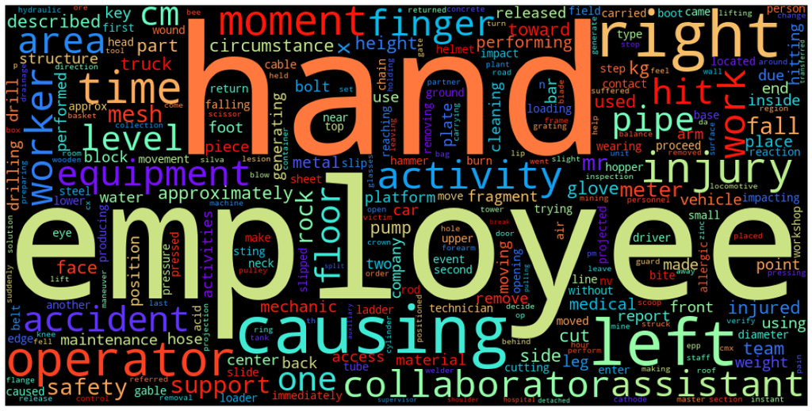

```python
from wordcloud import WordCloud
wordcloud = WordCloud(width = 1000, height = 500, random_state=5, background_color='Black', colormap='rainbow', \
                      min_font_size=5, max_words=300, collocations=False).generate(" ".join(df['Description'].values))
plt.figure(figsize=(20,10))
plt.imshow(wordcloud)
plt.axis('off')
plt.show()
```

1. Words which are related to human body like Hand,Head,Foot,Leg,Finger
2. Measurement words like Cm, Height, Kg
3. Type of employee related words like Employee Collaborator, assistant,Operator
4. Movement related words like,Left, Right, Fall,Hit, slip
5. Equipments related words like equipment, pump, meter, drill, truck
6. Accident related words accident, activity, safety, injury, causing

```python
from gensim.models import Word2Vec
```

```python
#Feature Engineering
from sklearn.feature_extraction.text import TfidfVectorizer
tfidf_df = pd.DataFrame()
for i in [1,2,3]:
    vec_tfidf = TfidfVectorizer(max_features=10, norm='l2', stop_words='english', lowercase=True, use_idf=True, ngram_range=(i,i))
    X = vec_tfidf.fit_transform(df['Description']).toarray()
    tfs = pd.DataFrame(X, columns=["TFIDF_" + n for n in vec_tfidf.get_feature_names_out()])
    tfidf_df = pd.concat([tfidf_df.reset_index(drop=True), tfs.reset_index(drop=True)], axis=1)

tfidf_df.head()
```

|  | TFIDF_activity | TFIDF_area | TFIDF_causing | TFIDF_employee | TFIDF_hand | TFIDF_injury | TFIDF_left | TFIDF_operator | TFIDF_right | TFIDF_time | ... | TFIDF_causing injury described | TFIDF_described time accident | TFIDF_finger left hand | TFIDF_finger right hand | TFIDF_generating described injury | TFIDF_hand causing injury | TFIDF_injury time accident | TFIDF_left hand causing | TFIDF_right hand causing | TFIDF_time accident employee |
| --- | --- | --- | --- | --- | --- | --- | --- | --- | --- | --- | --- | --- | --- | --- | --- | --- | --- | --- | --- | --- | --- |
| 0 | 0.0 | 0.000000 | 0.000000 | 0.0 | 0.000000 | 0.000000 | 0.000000 | 0.0 | 0.00000 | 0.0 | ... | 0.0 | 0.0 | 0.0 | 0.0 | 0.0 | 0.00000 | 0.0 | 0.000000 | 0.0 | 0.0 |
| 1 | 0.0 | 1.000000 | 0.000000 | 0.0 | 0.000000 | 0.000000 | 0.000000 | 0.0 | 0.00000 | 0.0 | ... | 0.0 | 0.0 | 0.0 | 0.0 | 0.0 | 0.00000 | 0.0 | 0.000000 | 0.0 | 0.0 |
| 2 | 0.0 | 0.553939 | 0.383344 | 0.0 | 0.412550 | 0.461166 | 0.404137 | 0.0 | 0.00000 | 0.0 | ... | 0.0 | 0.0 | 0.0 | 0.0 | 0.0 | 0.00000 | 0.0 | 0.000000 | 0.0 | 0.0 |
| 3 | 0.0 | 0.000000 | 0.349399 | 0.0 | 0.752037 | 0.420330 | 0.368351 | 0.0 | 0.00000 | 0.0 | ... | 0.0 | 0.0 | 0.0 | 0.0 | 0.0 | 0.69765 | 0.0 | 0.716438 | 0.0 | 0.0 |
| 4 | 0.0 | 0.000000 | 0.529535 | 0.0 | 0.000000 | 0.637035 | 0.000000 | 0.0 | 0.56016 | 0.0 | ... | 1.0 | 0.0 | 0.0 | 0.0 | 0.0 | 0.00000 | 0.0 | 0.000000 | 0.0 | 0.0 |

5 rows × 30 columns

```python
# To replace white space everywhere in Employee type
df['Employee type'] = df['Employee type'].str.replace(' ', '_')
df['Employee type'].value_counts()
```

```
Third_Party             185
Employee                178
Third_Party_(Remote)     55
Name: Employee type, dtype: int64
```

```python
# To replace white space everywhere in Critical Risk
df['Critical Risk'] = df['Critical Risk'].str.replace('\n', '').str.replace(' ', '_')
df['Critical Risk'].value_counts().head()
```

```
Others                 229
Pressed                 24
Manual_Tools            20
Chemical_substances     17
Cut                     14
Name: Critical Risk, dtype: int64
```

```python
from sklearn.preprocessing import LabelEncoder
# Create Industry DataFrame
ind_featenc_df = pd.DataFrame()

# Label encoding
df['Weekday'] = df['Weekday'].replace('Monday', 'aMonday').replace('Tuesday', 'bTuesday').replace('Wednesday', 'cWednesday').replace('Thursday', 'dThursday').replace('Friday', 'eFriday').replace('Saturday', 'fSaturday').replace('Sunday', 'gSunday')
ind_featenc_df['Weekday'] = LabelEncoder().fit_transform(df['Weekday']).astype(np.int8)

ind_featenc_df['Accident Level'] = LabelEncoder().fit_transform(df['Accident Level']).astype(np.int8)
ind_featenc_df['Potential Accident Level'] = LabelEncoder().fit_transform(df['Potential Accident Level']).astype(np.int8)
```

```python
# one hot encoded
from keras.utils import np_utils
dummy_y = np_utils.to_categorical(ind_featenc_df['Accident Level'])
dummy_y
```

```
array([[1., 0., 0., 0., 0.],
       [1., 0., 0., 0., 0.],
       [1., 0., 0., 0., 0.],
       ...,
       [1., 0., 0., 0., 0.],
       [1., 0., 0., 0., 0.],
       [1., 0., 0., 0., 0.]], dtype=float32)
```

```python
# Dummy variables encoding
Country_dummies = pd.get_dummies(df['Country'], columns=["Country"], drop_first=True)
Local_dummies = pd.get_dummies(df['Local'], columns=["Local"], drop_first=True)
Gender_dummies = pd.get_dummies(df['Gender'], columns=["Gender"], drop_first=True)
IS_dummies = pd.get_dummies(df['Industry Sector'], columns=['Industry Sector'], prefix='IS', drop_first=True)
EmpType_dummies = pd.get_dummies(df['Employee type'], columns=['Employee type'], prefix='EmpType', drop_first=True)
CR_dummies = pd.get_dummies(df['Critical Risk'], columns=['Critical Risk'], prefix='CR', drop_first=True)

# Merge the above dataframe with the original dataframe ind_feat_df
ind_featenc_df = ind_featenc_df.join(Country_dummies.reset_index(drop=True)).join(Local_dummies.reset_index(drop=True)).join(Gender_dummies.reset_index(drop=True)).join(IS_dummies.reset_index(drop=True)).join(EmpType_dummies.reset_index(drop=True)).join(CR_dummies.reset_index(drop=True))

ind_featenc_df = df[['Year','Month','Day','WeekofYear']].reset_index(drop=True).join(ind_featenc_df.reset_index(drop=True))

ind_featenc_df.head(3)
```

|  | Year | Month | Day | WeekofYear | Weekday | Accident Level | Potential Accident Level | Country_02 | Country_03 | Local_02 | ... | CR_Projection | CR_Projection/Burning | CR_Projection/Choco | CR_Projection/Manual_Tools | CR_Projection_of_fragments | CR_Suspended_Loads | CR_Traffic | CR_Vehicles_and_Mobile_Equipment | CR_Venomous_Animals | CR_remains_of_choco |
| --- | --- | --- | --- | --- | --- | --- | --- | --- | --- | --- | --- | --- | --- | --- | --- | --- | --- | --- | --- | --- | --- |
| 0 | 2016 | 1 | 1 | 53 | 4 | 0 | 3 | 0 | 0 | 0 | ... | 0 | 0 | 0 | 0 | 0 | 0 | 0 | 0 | 0 | 0 |
| 1 | 2016 | 1 | 2 | 53 | 5 | 0 | 3 | 1 | 0 | 1 | ... | 0 | 0 | 0 | 0 | 0 | 0 | 0 | 0 | 0 | 0 |
| 2 | 2016 | 1 | 6 | 1 | 2 | 0 | 2 | 0 | 0 | 0 | ... | 0 | 0 | 0 | 0 | 0 | 0 | 0 | 0 | 0 | 0 |

3 rows × 57 columns

```python
#Combine TFIDF and Encoded Feature
ind_feat_df = ind_featenc_df.join(tfidf_df.reset_index(drop=True))
ind_feat_df.head()
```

|  | Year | Month | Day | WeekofYear | Weekday | Accident Level | Potential Accident Level | Country_02 | Country_03 | Local_02 | ... | TFIDF_causing injury described | TFIDF_described time accident | TFIDF_finger left hand | TFIDF_finger right hand | TFIDF_generating described injury | TFIDF_hand causing injury | TFIDF_injury time accident | TFIDF_left hand causing | TFIDF_right hand causing | TFIDF_time accident employee |
| --- | --- | --- | --- | --- | --- | --- | --- | --- | --- | --- | --- | --- | --- | --- | --- | --- | --- | --- | --- | --- | --- |
| 0 | 2016 | 1 | 1 | 53 | 4 | 0 | 3 | 0 | 0 | 0 | ... | 0.0 | 0.0 | 0.0 | 0.0 | 0.0 | 0.00000 | 0.0 | 0.000000 | 0.0 | 0.0 |
| 1 | 2016 | 1 | 2 | 53 | 5 | 0 | 3 | 1 | 0 | 1 | ... | 0.0 | 0.0 | 0.0 | 0.0 | 0.0 | 0.00000 | 0.0 | 0.000000 | 0.0 | 0.0 |
| 2 | 2016 | 1 | 6 | 1 | 2 | 0 | 2 | 0 | 0 | 0 | ... | 0.0 | 0.0 | 0.0 | 0.0 | 0.0 | 0.00000 | 0.0 | 0.000000 | 0.0 | 0.0 |
| 3 | 2016 | 1 | 8 | 1 | 4 | 0 | 0 | 0 | 0 | 0 | ... | 0.0 | 0.0 | 0.0 | 0.0 | 0.0 | 0.69765 | 0.0 | 0.716438 | 0.0 | 0.0 |
| 4 | 2016 | 1 | 10 | 1 | 6 | 3 | 3 | 0 | 0 | 0 | ... | 1.0 | 0.0 | 0.0 | 0.0 | 0.0 | 0.00000 | 0.0 | 0.000000 | 0.0 | 0.0 |

5 rows × 87 columns

```python
X = ind_feat_df.drop(['Accident Level','Potential Accident Level'], axis = 1)
y = ind_feat_df['Accident Level']
```

```python
from sklearn.model_selection import train_test_split
X_train, X_test, y_train, y_test = train_test_split(X, y, test_size = 0.20, random_state = 1, stratify = y)
```

```python
X_train, X_test, y_train_dummy, y_test_dummy = train_test_split(X, dummy_y, test_size = 0.20, random_state = 1, stratify = y)
```

```python
print('X_train shape : ({0},{1})'.format(X_train.shape[0], X_train.shape[1]))
print('y_train shape : ({0},)'.format(y_train.shape[0]))
print('X_test shape : ({0},{1})'.format(X_test.shape[0], X_test.shape[1]))
print('y_test shape : ({0},)'.format(y_test.shape[0]))
```

```
X_train shape : (334,85)
y_train shape : (334,)
X_test shape : (84,85)
y_test shape : (84,)
```

```python
ind_feat_df['Accident Level'].value_counts()
```

```
0    309
1     40
2     31
3     30
4      8
Name: Accident Level, dtype: int64
```

```python
y_train_dummy
```

```
array([[0., 1., 0., 0., 0.],
       [0., 1., 0., 0., 0.],
       [1., 0., 0., 0., 0.],
       ...,
       [1., 0., 0., 0., 0.],
       [1., 0., 0., 0., 0.],
       [0., 1., 0., 0., 0.]], dtype=float32)
```

```python
# Combine training data back together
X_up = pd.concat([X_train, y_train], axis=1)
from sklearn.utils import resample

# Get the majority and minority class
acclevel_0_majority = X_up[X_up['Accident Level'] == 0]
acclevel_1_minority = X_up[X_up['Accident Level'] == 1]
acclevel_2_minority = X_up[X_up['Accident Level'] == 2]
acclevel_3_minority = X_up[X_up['Accident Level'] == 3]
acclevel_4_minority = X_up[X_up['Accident Level'] == 4]

# Upsample Level1 minority class
acclevel_1_minority_upsampled = resample(acclevel_1_minority,
                                replace = True, # sample with replacement
                                n_samples = len(acclevel_0_majority), # to match majority class
                                random_state = 1)

# Upsample Level2 minority class
acclevel_2_minority_upsampled = resample(acclevel_2_minority,
                                replace = True, # sample with replacement
                                n_samples = len(acclevel_0_majority), # to match majority class
                                random_state = 1)

# Upsample Level3 minority class
acclevel_3_minority_upsampled = resample(acclevel_3_minority,
                                replace = True, # sample with replacement
                                n_samples = len(acclevel_0_majority), # to match majority class
                                random_state = 1)

# Upsample Level4 minority class
acclevel_4_minority_upsampled = resample(acclevel_4_minority,
                                replace = True, # sample with replacement
                                n_samples = len(acclevel_0_majority), # to match majority class
                                random_state = 1)
```

```python
# Combine majority class with upsampled minority classes
df_upsampled = pd.concat([acclevel_0_majority, acclevel_1_minority_upsampled, acclevel_2_minority_upsampled, acclevel_3_minority_upsampled,
                          acclevel_4_minority_upsampled])
```

```python
# Display new accident level counts
df_upsampled['Accident Level'].value_counts()
```

```
0    247
1    247
2    247
3    247
4    247
Name: Accident Level, dtype: int64
```

```python
# Separate input features and target
X_train_up = df_upsampled.drop(['Accident Level'], axis = 1) # Considering all Predictors
y_train_up = df_upsampled['Accident Level']
```

```python
def multiclass_logloss(actual,predicted,eps=1e-15):
  """Multiclass version of log loss mteric
  parameter actual:Array containing actual target classes
  parameter predicted : Matrix with class predictions, one probabilty per calss"""
  #Convert Actual to binary array if its not already
  if len(actual.shape)==1:
    actual2=np.zeros((actual.shape[0],predicted.shape[1]))
    for i, val in enumerate(actual):
      actual2[i,val]=1
    actual=actual2

  clip = np.clip(predicted,eps,1-eps)
  rows = actual.shape[0]
  vsota=np.sum(actual*np.log(clip))
  return -1.0/rows*vsota
```

```python
import warnings
warnings.filterwarnings('ignore')

def train_test_model(model, method, X_train,X_test,y_train, y_test,of_type,index,scale,report,save_model):
  if report=="yes":
    print(model)
    print("----------------------------------------------------------------")
  if method=='CatBoostClassifier' or method == 'LGBMClassifier':
    model.fit(X_train, y_train)
  else:
    model.fit(X_train,y_train)

  from sklearn.metrics import accuracy_score, f1_score, confusion_matrix, recall_score, precision_score
  from sklearn.metrics import classification_report
  import pickle


  if of_type=="coef":
    print("Intercept of model is{}".format(model.intercept_),"\n")
    for idx , col_name in enumerate(X_train.columns):
      print("the Coefficient for {} is{} ".format(col_name,model.coef_.ravel()[idx]))

  y_pred = model.predict(X_test)

  mc_logloss=1.00
  if method != 'RidgeClassifier':
    y_predictions = model.predict_proba(X_test)
    mc_logloss = multiclass_logloss(y_test, y_predictions, eps=1e-15)

  train_accuracy_score = model.score(X_train, y_train)
  test_accuracy_score = model.score(X_test, y_test)

  precision_score = precision_score(y_test, y_pred, average='weighted')
  recall_score = recall_score(y_test, y_pred, average='weighted')
  f1_score = f1_score(y_test, y_pred, average='weighted')

  if report=="yes":
    model_cm = confusion_matrix(y_test, y_pred)
    sns.heatmap(model_cm,annot=True,fmt=".2f",xticklabels=["I", "II", "III", "IV", "V"],yticklabels=["I", "II", "III", "IV", "V"])
    plt.ylabel('Actual')
    plt.xlabel('Predicted')
    plt.show()
    model_cr = classification_report(y_test, y_pred)
    print(model_cr)

  resultsDf=pd.DataFrame({"Method":method,"Train_Accuracy":train_accuracy_score,"Test_Accuracy":test_accuracy_score,"Precision score":precision_score,"Recall":recall_score,"F1score":f1_score},index=[index])

  if save_model == "yes":
    filename = 'finalised_model.sav'
    pickle.dump(model, open(filename, 'wb'))
  return resultsDf
```

```python
import lightgbm as lgb

def train_test_allmodels(X_train_common,X_test_common,y_train,y_test,scale):
  print("Machine learning classifiers")
  print("************************************************************** ")

  models=[
          ['Logistic regression',LogisticRegression(solver='lbfgs', multi_class='multinomial', random_state = 1)],
          ['RidgeClassifier',RidgeClassifier(random_state = 1)],
          ['KNeighborsClassifier',KNeighborsClassifier(n_neighbors = 3)],
          ['SVC',SVC(kernel = 'rbf', probability=True)],
          ['DecisionTreeClassifier',DecisionTreeClassifier(criterion = 'gini', random_state=1)],
          ['RandomForestClassifier',RandomForestClassifier(n_estimators=10, random_state=1)],
          ['BaggingClassifier',BaggingClassifier(n_estimators=30, max_samples=0.75, random_state=1, oob_score=True)],
          ['AdaBoostClassifier',AdaBoostClassifier(n_estimators=100, learning_rate=0.25, random_state=1)],
          ['GradientBoostingClassifier',GradientBoostingClassifier(loss='deviance', n_estimators=50, learning_rate=0.1, validation_fraction=0.2,random_state=1)],
          ['LGBMClassifier',LGBMClassifier(random_state=1, metric = "multi_logloss", objective="multiclass")],
          ['XGBClassifier',XGBClassifier(min_child_weight = 7, max_depth = 6, objective="multi:softmax", learning_rate = 0.1, gamma = 0.4, colsample_bytree = 0.5)]
          ]
  resultsDf_common = pd.DataFrame()
  i=1
  for name, classifier in models:
    reg_resultsDf = train_test_model(classifier, name, X_train_common, X_test_common, y_train, y_test, 'none', i, scale, 'no', 'no')
    resultsDf_common = pd.concat([resultsDf_common, reg_resultsDf])
    i= i+1
  return resultsDf_common
```

Modelling - Logistic Regression

```
LogisticRegression(multi_class='multinomial', random_state=1)
----------------------------------------------------------------
```

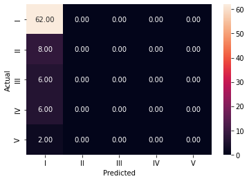

```
              precision    recall  f1-score   support

           0       0.74      1.00      0.85        62
           1       0.00      0.00      0.00         8
           2       0.00      0.00      0.00         6
           3       0.00      0.00      0.00         6
           4       0.00      0.00      0.00         2

    accuracy                           0.74        84
   macro avg       0.15      0.20      0.17        84
weighted avg       0.54      0.74      0.63        84
```

|  | Method | Train_Accuracy | Test_Accuracy | Precision score | Recall | F1score |
| --- | --- | --- | --- | --- | --- | --- |
| 1 | Logistic Regression without Sampling | 0.739521 | 0.738095 | 0.544785 | 0.738095 | 0.626875 |

```python
from sklearn.linear_model import LogisticRegression
resultsDf = pd.DataFrame()
# Building a Linear Regression model
lr = LogisticRegression(solver='lbfgs', multi_class='multinomial', random_state = 1)

# Train and Test the model
resultsDf = train_test_model(lr, 'Logistic Regression without Sampling', X_train, X_test, y_train, y_test, 'none', 1, 'no', 'yes', 'no')

# Store the accuracy results for each model in a dataframe for final comparison
resultsDf
```

```python
from sklearn.linear_model import RidgeClassifier
from sklearn.neighbors import KNeighborsClassifier
from sklearn.naive_bayes import GaussianNB
from sklearn.svm import SVC
from sklearn.tree import DecisionTreeClassifier
# ensemble models
from sklearn.ensemble import RandomForestClassifier
from sklearn.ensemble import BaggingClassifier
from sklearn.ensemble import AdaBoostClassifier
from sklearn.ensemble import GradientBoostingClassifier
from lightgbm import LGBMClassifier
from xgboost import XGBClassifier
```

Random Forest with original *data*

```
RandomForestClassifier(n_estimators=10, random_state=1)
----------------------------------------------------------------
```

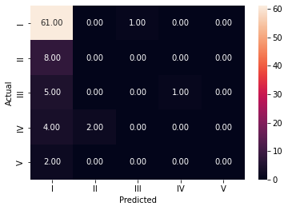

```
              precision    recall  f1-score   support

           0       0.76      0.98      0.86        62
           1       0.00      0.00      0.00         8
           2       0.00      0.00      0.00         6
           3       0.00      0.00      0.00         6
           4       0.00      0.00      0.00         2

    accuracy                           0.73        84
   macro avg       0.15      0.20      0.17        84
weighted avg       0.56      0.73      0.63        84
```

|  | Method | Train_Accuracy | Test_Accuracy | Precision score | Recall | F1score |
| --- | --- | --- | --- | --- | --- | --- |
| 1 | Logistic Regression without Sampling | 0.739521 | 0.738095 | 0.544785 | 0.738095 | 0.626875 |
| 2 | Random Forest with original data | 0.967066 | 0.726190 | 0.562798 | 0.726190 | 0.634138 |

```python
# Building a Random Forest Classifier on Training set
rfc_model = RandomForestClassifier(n_estimators=10, random_state=1)

# Train and Test the model
rf_df = train_test_model(rfc_model, 'Random Forest with original data', X_train, X_test, y_train, y_test, 'none', 2, 'no', 'yes', 'no')

#Store the accuracy results for each model in a dataframe for final comparison
resultsDf = pd.concat([resultsDf,rf_df])
resultsDf
```

Logistic Regression with Sampling

```
LogisticRegression(multi_class='multinomial', random_state=1)
----------------------------------------------------------------
```

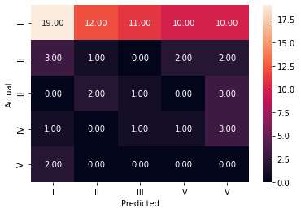

```
              precision    recall  f1-score   support

           0       0.76      0.31      0.44        62
           1       0.07      0.12      0.09         8
           2       0.08      0.17      0.11         6
           3       0.08      0.17      0.11         6
           4       0.00      0.00      0.00         2

    accuracy                           0.26        84
   macro avg       0.20      0.15      0.15        84
weighted avg       0.58      0.26      0.35        84
```

|  | Method | Train_Accuracy | Test_Accuracy | Precision score | Recall | F1score |
| --- | --- | --- | --- | --- | --- | --- |
| 1 | Logistic Regression without Sampling | 0.739521 | 0.738095 | 0.544785 | 0.738095 | 0.626875 |
| 2 | Random Forest with original data | 0.967066 | 0.726190 | 0.562798 | 0.726190 | 0.634138 |
| 3 | Logistic Regression with Sampling | 0.381377 | 0.261905 | 0.578291 | 0.261905 | 0.345706 |

```python
# Building a Linear Regression model
lr = LogisticRegression(solver='lbfgs', multi_class='multinomial', random_state = 1)

# Train and Test the model
lr_df = train_test_model(lr, 'Logistic Regression with Sampling', X_train_up, X_test, y_train_up, y_test, 'none', 3, 'no', 'yes', 'no')

#Store the accuracy results for each model in a dataframe for final comparison
resultsDf = pd.concat([resultsDf,lr_df])
resultsDf
```

## 1. All Models With Original data

```python
train_test_allmodels(X_train, X_test, y_train, y_test, 'no')
```

```
Machine learning classifiers
```

|  | Method | Train_Accuracy | Test_Accuracy | Precision score | Recall | F1score |
| --- | --- | --- | --- | --- | --- | --- |
| 1 | Logistic regression | 0.739521 | 0.738095 | 0.544785 | 0.738095 | 0.626875 |
| 2 | RidgeClassifier | 0.757485 | 0.726190 | 0.555850 | 0.726190 | 0.629704 |
| 3 | KNeighborsClassifier | 0.754491 | 0.690476 | 0.567177 | 0.690476 | 0.622429 |
| 4 | SVC | 0.739521 | 0.738095 | 0.544785 | 0.738095 | 0.626875 |
| 5 | DecisionTreeClassifier | 0.994012 | 0.654762 | 0.638983 | 0.654762 | 0.646408 |
| 6 | RandomForestClassifier | 0.967066 | 0.726190 | 0.562798 | 0.726190 | 0.634138 |
| 7 | BaggingClassifier | 0.961078 | 0.714286 | 0.546737 | 0.714286 | 0.619381 |
| 8 | AdaBoostClassifier | 0.736527 | 0.714286 | 0.627396 | 0.714286 | 0.650885 |
| 9 | GradientBoostingClassifier | 0.934132 | 0.714286 | 0.658175 | 0.714286 | 0.658399 |
| 10 | LGBMClassifier | 0.991018 | 0.750000 | 0.650000 | 0.750000 | 0.690951 |
| 11 | XGBClassifier | 0.826347 | 0.750000 | 0.632784 | 0.750000 | 0.676386 |

## 2. All Models With Oversampling

```python
train_test_allmodels(X_train_up, X_test, y_train_up, y_test, 'no')
```

```
Machine learning classifiers
```

|  | Method | Train_Accuracy | Test_Accuracy | Precision score | Recall | F1score |
| --- | --- | --- | --- | --- | --- | --- |
| 1 | Logistic regression | 0.381377 | 0.261905 | 0.578291 | 0.261905 | 0.345706 |
| 2 | RidgeClassifier | 0.800000 | 0.392857 | 0.705034 | 0.392857 | 0.489311 |
| 3 | KNeighborsClassifier | 0.951417 | 0.404762 | 0.619183 | 0.404762 | 0.475959 |
| 4 | SVC | 0.289069 | 0.071429 | 0.025661 | 0.071429 | 0.033149 |
| 5 | DecisionTreeClassifier | 0.998381 | 0.630952 | 0.632864 | 0.630952 | 0.629707 |
| 6 | RandomForestClassifier | 0.998381 | 0.761905 | 0.700000 | 0.761905 | 0.711525 |
| 7 | BaggingClassifier | 0.998381 | 0.726190 | 0.673964 | 0.726190 | 0.698871 |
| 8 | AdaBoostClassifier | 0.365992 | 0.690476 | 0.559988 | 0.690476 | 0.618043 |
| 9 | GradientBoostingClassifier | 0.968421 | 0.523810 | 0.636409 | 0.523810 | 0.565801 |
| 10 | LGBMClassifier | 0.998381 | 0.714286 | 0.639456 | 0.714286 | 0.674315 |
| 11 | XGBClassifier | 0.995142 | 0.619048 | 0.624642 | 0.619048 | 0.621409 |

By comparing the results from all above methods,RandomForestClassifier is performing better with F1 score of 71.1% but overfit in training set